# Taller 2 y 3 de fundamentos de programación.

Por otra parte, la region de Europa y Asia central cuentan con una distribución de expectativa de vida y con un promedio de vida mayor al de las regiones anteriores y cercano a los 80 años, pero con una minoria importante de países entre los 70 y 75 años, esto se debe a que a pesar de que Europa, en especial, Europa Occidental es una región bastante desarrollada en términos economicos, sociales y políticos y es una de las regiones más importantes del mundo, la región de Asia Central tiene páises periféricos con un nivel de desarrollo social, económico y político mucho menor como Turmenkistán o Kirguistán.

Por último, la región de Norteamérica tiene una distribución bastante consolidada en una expectativa de vida cercana a los 80 años, esto se debe a que igual que Europa, es otra region bastante desarrollada en terminos sociales, economicos y políticos y tambien es una de las regiones más importantes en términos económicos, basicamente por los países de Canadá y Estados Unidos que son países muy desarrollados y con un nivel de vida elevado.

16. Descargue lOS microdatos de la Gran Encuesta Integrada de Hogares para el mes de febrero de 2021. Use un loop for para importar los datos que corresponden a los módulos cabecera y resto.

```r
y <- list.files("Febrero GEIH/")
# Febrero GEIH es el nombre de la carpeta descargada con los microdatos de la Gran Encuesta Integrada de Hogares para el mes de febrero de 2021.
x <- c()
for (i in seq_along(y)) {
  x[i] <- paste0("w",i)
  z <- read_delim(paste0("Febrero GEIH/",y[i]),delim = ";")
  assign(x[i],z)
}
head(y)
```

```
## [1] "area- Fuerza de trabajo.csv"
## [2] "area - Caracteristicas generales (Personas).csv"
## [3] "area - Desocupados.csv"
## [4] "area - Inactivos.csv"
## [5] "area - Ocupados.csv"
## [6] "area - Otras actividades y ayudas en la semana.csv"
```

```r
#View(y)
```

Para los módulos de cabecera, una el módulo de características generales (personas) y el de vivienda y hogares.

```r
v <- left_join(w1,w8, by = c("DIRECTORIO","SECUENCIA_P"))

for (i in 2:7) {
  v <- left_join(v,get(paste0("w",i)),by = c("DIRECTORIO","SECUENCIA_P","ORDEN"))
}
head(v)
```

| DIRECTORIO | SECUENCIA_P | ORDEN | HOGAR.x | REGIS.x | AREA.x | P6290 | P6290S1 | P6230 | P6240 | P6240S1 | P6250 | P6260 | P6270 | P6280 | P6300 | P6310 | P6310S1 | P6320 | P6330 | P6340 | P6350 | P6351 | MES.x | FT | DPTO.x | fex_c_2011.x | P5000 | P5010 | P5020 | … |
| --- | --- | --- | --- | --- | --- | --- | --- | --- | --- | --- | --- | --- | --- | --- | --- | --- | --- | --- | --- | --- | --- | --- | --- | --- | --- | --- | --- | --- | --- | --- |
| 5367062 | 1 | 1 | 1 | 50 | 05 | NA | NA | 1 | 6 | AUTOCONSTRUCCION DE VIVIENDA | 2 | 2 | 2 | 2 | 1 | 13 | ESTA ESPERANDO TERMINAR DE CONSTRUIR SU VIVIENDA | NA | NA | NA | NA | NA | 02 | 1 | 05 | 1.062935e+13 | 3 | 2 | 1 | … |
| 5367063 | 1 | 1 | 1 | 50 | 05 | NA | NA | 1 | 4 | NA | 2 | 2 | 2 | 2 | 2 | NA | NA | NA | NA | NA | NA | NA | 02 | 1 | 05 | 1.157189e+14 | 4 | 3 | 1 | … |
| 5367063 | 1 | 2 | 1 | 50 | 05 | 1 | NA | 2 | 6 | VER TV | 2 | 2 | 2 | 1 | NA | NA | NA | NA | NA | NA | NA | 1 | 02 | 1 | 05 | 1.157189e+14 | 4 | 3 | 1 | … |
| 5367063 | 1 | 3 | 1 | 50 | 05 | NA | NA | 3 | 4 | NA | 2 | 2 | 2 | 2 | 1 | 5 | NA | 2 | NA | 1 | 2 | 1 | 02 | 1 | 05 | 1.157189e+14 | 4 | 3 | 1 | … |
| 5367064 | 1 | 1 | 1 | 50 | 05 | NA | NA | 1 | 4 | NA | 1 | NA | NA | NA | NA | NA | NA | NA | NA | NA | NA | NA | 02 | 1 | 05 | 1.307234e+14 | 3 | 3 | 1 | … |
| 5367064 | 1 | 2 | 1 | 50 | 05 | NA | NA | 2 | 3 | NA | 2 | 2 | 2 | 2 | 2 | NA | NA | NA | NA | NA | NA | NA | 02 | 1 | 05 | 1.307234e+14 | 3 | 3 | 1 | … |

```r
#View(v)
```

Después, use un loop for para unir los módulos restantes. Repita el mismo ejercicio para los módulos de resto. Cuando haya terminado, una cabecera y resto usando la función bind_rows. Al final, tendrá la información nacional de la GEIH para el mes de febrero de 2021.

```r
u <- left_join(w9,w16, by = c("DIRECTORIO","SECUENCIA_P"))

for (i in 10:15) {
  u <- left_join(u,get(paste0("w",i)),by = c("DIRECTORIO","SECUENCIA_P","ORDEN"))
}
head(u)
```

| DIRECTORIO | SECUENCIA_P | ORDEN | HOGAR.x | REGIS.x | P6016 | P6020 | P6030S1 | P6030S3 | P6040 | P6050 | P6080 | P6080S1 | P6070 | P6081 | P6081S1 | P6083 | P6083S1 | P6071 | P6071S1 | P3147S1 | P3147S2 | P3147S3 | P3147S4 | P3147S5 | P3147S6 | P3147S7 | P3147S8 | P3147S9 | P3147S10 | … |
| --- | --- | --- | --- | --- | --- | --- | --- | --- | --- | --- | --- | --- | --- | --- | --- | --- | --- | --- | --- | --- | --- | --- | --- | --- | --- | --- | --- | --- | --- | --- |
| 5367027 | 1 | 1 | 1 | 10 | 1 | 2 | 12 | 1968 | 52 | 1 | 6 | NA | 2 | 3 | NA | 2 | NA | 1 | 2 | NA | 1 | 1 | 1 | NA | NA | NA | NA | 1 | NA | … |
| 5367027 | 1 | 2 | 1 | 10 | 2 | 1 | 12 | 1973 | 47 | 2 | 6 | NA | 2 | 3 | NA | 3 | NA | 1 | 1 | NA | NA | NA | 1 | NA | NA | NA | NA | NA | NA | … |
| 5367028 | 1 | 1 | 1 | 10 | 1 | 2 | 4 | 1964 | 56 | 1 | 6 | NA | 4 | 3 | NA | 3 | NA | NA | NA | 1 | 1 | NA | 1 | NA | NA | NA | NA | NA | NA | … |
| 5367028 | 1 | 2 | 1 | 10 | 2 | 1 | 12 | 1996 | 24 | 3 | 6 | NA | 1 | 3 | NA | 1 | 1 | 1 | 3 | NA | 1 | 1 | 1 | 1 | 1 | 1 | NA | NA | NA | … |
| 5367028 | 1 | 3 | 1 | 10 | 3 | 2 | 3 | 2001 | 19 | 5 | 6 | NA | 1 | 2 | NA | 2 | NA | 1 | 2 | NA | 1 | 1 | 1 | 1 | NA | 1 | NA | NA | NA | … |
| 5367028 | 1 | 4 | 1 | 10 | 3 | 1 | 11 | 2019 | 1 | 4 | 6 | NA | NA | 1 | 2 | 1 | 3 | NA | NA | NA | NA | NA | NA | NA | NA | NA | NA | NA | NA | … |

```r
#View(u)
```

```r
febrero <- bind_rows(v,u)
head(febrero)
```

| DIRECTORIO | SECUENCIA_P | ORDEN | HOGAR.x | REGIS.x | AREA.x | P6290 | P6290S1 | P6230 | P6240 | P6240S1 | P6250 | P6260 | P6270 | P6280 | P6300 | P6310 | P6310S1 | P6320 | P6330 | P6340 | P6350 | P6351 | MES.x | FT | DPTO.x | fex_c_2011.x | P5000 | P5010 | P5020 | … |
| --- | --- | --- | --- | --- | --- | --- | --- | --- | --- | --- | --- | --- | --- | --- | --- | --- | --- | --- | --- | --- | --- | --- | --- | --- | --- | --- | --- | --- | --- | --- |
| 5367062 | 1 | 1 | 1 | 50 | 05 | NA | NA | 1 | 6 | AUTOCONSTRUCCION DE VIVIENDA | 2 | 2 | 2 | 2 | 1 | 13 | ESTA ESPERANDO TERMINAR DE CONSTRUIR SU VIVIENDA | NA | NA | NA | NA | NA | 02 | 1 | 05 | 1.062935e+13 | 3 | 2 | 1 | … |
| 5367063 | 1 | 1 | 1 | 50 | 05 | NA | NA | 1 | 4 | NA | 2 | 2 | 2 | 2 | 2 | NA | NA | NA | NA | NA | NA | NA | 02 | 1 | 05 | 1.157189e+14 | 4 | 3 | 1 | … |
| 5367063 | 1 | 2 | 1 | 50 | 05 | 1 | NA | 2 | 6 | VER TV | 2 | 2 | 2 | 1 | NA | NA | NA | NA | NA | NA | NA | 1 | 02 | 1 | 05 | 1.157189e+14 | 4 | 3 | 1 | … |
| 5367063 | 1 | 3 | 1 | 50 | 05 | NA | NA | 3 | 4 | NA | 2 | 2 | 2 | 2 | 1 | 5 | NA | 2 | NA | 1 | 2 | 1 | 02 | 1 | 05 | 1.157189e+14 | 4 | 3 | 1 | … |
| 5367064 | 1 | 1 | 1 | 50 | 05 | NA | NA | 1 | 4 | NA | 1 | NA | NA | NA | NA | NA | NA | NA | NA | NA | NA | NA | 02 | 1 | 05 | 1.307234e+14 | 3 | 3 | 1 | … |
| 5367064 | 1 | 2 | 1 | 50 | 05 | NA | NA | 2 | 3 | NA | 2 | 2 | 2 | 2 | 2 | NA | NA | NA | NA | NA | NA | NA | 02 | 1 | 05 | 1.307234e+14 | 3 | 3 | 1 | … |

```r
#View(febrero)
```

17. Usando la base resultante en el punto anterior, emplee la función mutate, en conjunto con la función across para convertir en factor las variables P6250, P6020, P6440, P7310, y P7439 (Revisen el diccionario de datos para ver el contenido de cada una de estas variables). En cada una de estas variables la categoría 1 debe tener la etiqueta Sí, y la categoría 2 debe tener la etiqueta No.

```r
febrero <- febrero %>%
  mutate(across(.cols = c(P6250, P6020, P6440, P7310,P7430), .fns= factor)) %>%
  mutate(across(.cols = c(P6250, P6020, P6440,
P7310,P7430), ~recode(.x,"1"="sí","2"="no")))
head(febrero)
```

| DIRECTORIO | SECUENCIA_P | ORDEN | HOGAR.x | REGIS.x | AREA.x | P6290 | P6290S1 | P6230 | P6240 | P6240S1 | P6250 | P6260 | P6270 | P6280 | P6300 | P6310 | P6310S1 | P6320 | P6330 | P6340 | P6350 | P6351 | MES.x | FT | DPTO.x | fex_c_2011.x | P5000 | P5010 | P5020 | … |
| --- | --- | --- | --- | --- | --- | --- | --- | --- | --- | --- | --- | --- | --- | --- | --- | --- | --- | --- | --- | --- | --- | --- | --- | --- | --- | --- | --- | --- | --- | --- |
| 5367062 | 1 | 1 | 1 | 50 | 05 | NA | NA | 1 | 6 | AUTOCONSTRUCCION DE VIVIENDA | no | 2 | 2 | 2 | 1 | 13 | ESTA ESPERANDO TERMINAR DE CONSTRUIR SU VIVIENDA | NA | NA | NA | NA | NA | 02 | 1 | 05 | 1.062935e+13 | 3 | 2 | 1 | … |
| 5367063 | 1 | 1 | 1 | 50 | 05 | NA | NA | 1 | 4 | NA | no | 2 | 2 | 2 | 2 | NA | NA | NA | NA | NA | NA | NA | 02 | 1 | 05 | 1.157189e+14 | 4 | 3 | 1 | … |
| 5367063 | 1 | 2 | 1 | 50 | 05 | 1 | NA | 2 | 6 | VER TV | no | 2 | 2 | 1 | NA | NA | NA | NA | NA | NA | NA | 1 | 02 | 1 | 05 | 1.157189e+14 | 4 | 3 | 1 | … |
| 5367063 | 1 | 3 | 1 | 50 | 05 | NA | NA | 3 | 4 | NA | no | 2 | 2 | 2 | 1 | 5 | NA | 2 | NA | 1 | 2 | 1 | 02 | 1 | 05 | 1.157189e+14 | 4 | 3 | 1 | … |
| 5367064 | 1 | 1 | 1 | 50 | 05 | NA | NA | 1 | 4 | NA | sí | NA | NA | NA | NA | NA | NA | NA | NA | NA | NA | NA | 02 | 1 | 05 | 1.307234e+14 | 3 | 3 | 1 | … |
| 5367064 | 1 | 2 | 1 | 50 | 05 | NA | NA | 2 | 3 | NA | no | 2 | 2 | 2 | 2 | NA | NA | NA | NA | NA | NA | NA | 02 | 1 | 05 | 1.307234e+14 | 3 | 3 | 1 | … |

```r
#VIew(febrero)
```

18. 1. Importen la base de datos de contagios de la Covid 19 para Colombia. Pueden usar la siguiente función:

```r
covid_19 <- read_csv("https://www.datos.gov.co/api/views/gt2j-8ykr/rows.csv?accessType=DOWNLOAD")
head(covid_19)
```

| fecha reporte web | ID de caso | Fecha de notificación | Código DIVIPOLA departamento | Nombre departamento | Código DIVIPOLA municipio | Nombre municipio | Edad | Unidad de medida de edad | Sexo | Tipo de contagio | Ubicación del caso | Estado | Código ISO del país | Nombre del país | Recuperado | Fecha de inicio de síntomas | Fecha de muerte | Fecha de diagnóstico | Fecha de recuperación | Tipo de recuperación | Pertenencia étnica | Nombre del grupo étnico |
| --- | --- | --- | --- | --- | --- | --- | --- | --- | --- | --- | --- | --- | --- | --- | --- | --- | --- | --- | --- | --- | --- | --- |
| 6/3/2020 0:00:00 | 1 | 2/3/2020 0:00:00 | 11 | BOGOTA | 11001 | BOGOTA | 19 | 1 | F | Importado | Casa | Leve | 380 | ITALIA | Recuperado | 27/2/2020 0:00:00 | NA | 6/3/2020 0:00:00 | 13/3/2020 0:00:00 | PCR | 6 | NA |
| 9/3/2020 0:00:00 | 2 | 6/3/2020 0:00:00 | 76 | VALLE | 76111 | BUGA | 34 | 1 | M | Importado | Casa | Leve | 724 | ESPAÑA | Recuperado | 4/3/2020 0:00:00 | NA | 9/3/2020 0:00:00 | 19/3/2020 0:00:00 | PCR | 5 | NA |
| 9/3/2020 0:00:00 | 3 | 7/3/2020 0:00:00 | 5 | ANTIOQUIA | 5001 | MEDELLIN | 50 | 1 | F | Importado | Casa | Leve | 724 | ESPAÑA | Recuperado | 29/2/2020 0:00:00 | NA | 9/3/2020 0:00:00 | 15/3/2020 0:00:00 | PCR | 6 | NA |
| 11/3/2020 0:00:00 | 4 | 9/3/2020 0:00:00 | 5 | ANTIOQUIA | 5001 | MEDELLIN | 55 | 1 | M | Relacionado | Casa | Leve | NA | NA | Recuperado | 6/3/2020 0:00:00 | NA | 11/3/2020 0:00:00 | 26/3/2020 0:00:00 | PCR | 6 | NA |
| 11/3/2020 0:00:00 | 5 | 9/3/2020 0:00:00 | 5 | ANTIOQUIA | 5001 | MEDELLIN | 25 | 1 | M | Relacionado | Casa | Leve | NA | NA | Recuperado | 8/3/2020 0:00:00 | NA | 11/3/2020 0:00:00 | 23/3/2020 0:00:00 | PCR | 6 | NA |
| 11/3/2020 0:00:00 | 6 | 10/3/2020 0:00:00 | 5 | ANTIOQUIA | 5360 | ITAGUI | 27 | 1 | F | Relacionado | Casa | Leve | NA | NA | Recuperado | 6/3/2020 0:00:00 | NA | 11/3/2020 0:00:00 | 26/3/2020 0:00:00 | PCR | 6 | NA |

```r
#View(covid_19)
```

2. Cambien el nombre a la variable fecha reporte web a fecha_reporte.

```r
covid19 <- covid_19 %>% rename(fecha_reporte =`fecha reporte web`)
head(covid19)
```

| fecha_reporte | ID de caso | Fecha de notificación | Código DIVIPOLA departamento | Nombre departamento | Código DIVIPOLA municipio | Nombre municipio | Edad | Unidad de medida de edad | Sexo | Tipo de contagio | Ubicación del caso | Estado | Código ISO del país | Nombre del país | Recuperado | Fecha de inicio de síntomas | Fecha de muerte | Fecha de diagnóstico | Fecha de recuperación | Tipo de recuperación | Pertenencia étnica | Nombre del grupo étnico |
| --- | --- | --- | --- | --- | --- | --- | --- | --- | --- | --- | --- | --- | --- | --- | --- | --- | --- | --- | --- | --- | --- | --- |
| 6/3/2020 0:00:00 | 1 | 2/3/2020 0:00:00 | 11 | BOGOTA | 11001 | BOGOTA | 19 | 1 | F | Importado | Casa | Leve | 380 | ITALIA | Recuperado | 27/2/2020 0:00:00 | NA | 6/3/2020 0:00:00 | 13/3/2020 0:00:00 | PCR | 6 | NA |
| 9/3/2020 0:00:00 | 2 | 6/3/2020 0:00:00 | 76 | VALLE | 76111 | BUGA | 34 | 1 | M | Importado | Casa | Leve | 724 | ESPAÑA | Recuperado | 4/3/2020 0:00:00 | NA | 9/3/2020 0:00:00 | 19/3/2020 0:00:00 | PCR | 5 | NA |
| 9/3/2020 0:00:00 | 3 | 7/3/2020 0:00:00 | 5 | ANTIOQUIA | 5001 | MEDELLIN | 50 | 1 | F | Importado | Casa | Leve | 724 | ESPAÑA | Recuperado | 29/2/2020 0:00:00 | NA | 9/3/2020 0:00:00 | 15/3/2020 0:00:00 | PCR | 6 | NA |
| 11/3/2020 0:00:00 | 4 | 9/3/2020 0:00:00 | 5 | ANTIOQUIA | 5001 | MEDELLIN | 55 | 1 | M | Relacionado | Casa | Leve | NA | NA | Recuperado | 6/3/2020 0:00:00 | NA | 11/3/2020 0:00:00 | 26/3/2020 0:00:00 | PCR | 6 | NA |
| 11/3/2020 0:00:00 | 5 | 9/3/2020 0:00:00 | 5 | ANTIOQUIA | 5001 | MEDELLIN | 25 | 1 | M | Relacionado | Casa | Leve | NA | NA | Recuperado | 8/3/2020 0:00:00 | NA | 11/3/2020 0:00:00 | 23/3/2020 0:00:00 | PCR | 6 | NA |
| 11/3/2020 0:00:00 | 6 | 10/3/2020 0:00:00 | 5 | ANTIOQUIA | 5360 | ITAGUI | 27 | 1 | F | Relacionado | Casa | Leve | NA | NA | Recuperado | 6/3/2020 0:00:00 | NA | 11/3/2020 0:00:00 | 26/3/2020 0:00:00 | PCR | 6 | NA |

```r
#View(covid19)
```

3. Asegúrese de que la variable fecha_reporte es identificada por R como una fecha.

```r
Covid_19 <- covid19 %>%
  separate(fecha_reporte, c("fecha_reporte", "hora"), " ") %>%
  select(-"hora") %>%
  mutate(fecha_reporte1 = dmy(fecha_reporte)) %>%
  select(-fecha_reporte)
class(Covid_19$fecha_reporte1)
```

```
## [1] "Date"
```

```r
head(Covid_19)
```

| ID de caso | Fecha de notificación | Código DIVIPOLA departamento | Nombre departamento | Código DIVIPOLA municipio | Nombre municipio | Edad | Unidad de medida de edad | Sexo | Tipo de contagio | Ubicación del caso | Estado | Código ISO del país | Nombre del país | Recuperado | Fecha de inicio de síntomas | Fecha de muerte | Fecha de diagnóstico | Fecha de recuperación | Tipo de recuperación | Pertenencia étnica | Nombre del grupo étnico | fecha_reporte1 |
| --- | --- | --- | --- | --- | --- | --- | --- | --- | --- | --- | --- | --- | --- | --- | --- | --- | --- | --- | --- | --- | --- | --- |
| 1 | 2/3/2020 0:00:00 | 11 | BOGOTA | 11001 | BOGOTA | 19 | 1 | F | Importado | Casa | Leve | 380 | ITALIA | Recuperado | 27/2/2020 0:00:00 | NA | 6/3/2020 0:00:00 | 13/3/2020 0:00:00 | PCR | 6 | NA | 2020-03-06 |
| 2 | 6/3/2020 0:00:00 | 76 | VALLE | 76111 | BUGA | 34 | 1 | M | Importado | Casa | Leve | 724 | ESPAÑA | Recuperado | 4/3/2020 0:00:00 | NA | 9/3/2020 0:00:00 | 19/3/2020 0:00:00 | PCR | 5 | NA | 2020-03-09 |
| 3 | 7/3/2020 0:00:00 | 5 | ANTIOQUIA | 5001 | MEDELLIN | 50 | 1 | F | Importado | Casa | Leve | 724 | ESPAÑA | Recuperado | 29/2/2020 0:00:00 | NA | 9/3/2020 0:00:00 | 15/3/2020 0:00:00 | PCR | 6 | NA | 2020-03-09 |
| 4 | 9/3/2020 0:00:00 | 5 | ANTIOQUIA | 5001 | MEDELLIN | 55 | 1 | M | Relacionado | Casa | Leve | NA | NA | Recuperado | 6/3/2020 0:00:00 | NA | 11/3/2020 0:00:00 | 26/3/2020 0:00:00 | PCR | 6 | NA | 2020-03-11 |
| 5 | 9/3/2020 0:00:00 | 5 | ANTIOQUIA | 5001 | MEDELLIN | 25 | 1 | M | Relacionado | Casa | Leve | NA | NA | Recuperado | 8/3/2020 0:00:00 | NA | 11/3/2020 0:00:00 | 23/3/2020 0:00:00 | PCR | 6 | NA | 2020-03-11 |
| 6 | 10/3/2020 0:00:00 | 5 | ANTIOQUIA | 5360 | ITAGUI | 27 | 1 | F | Relacionado | Casa | Leve | NA | NA | Recuperado | 6/3/2020 0:00:00 | NA | 11/3/2020 0:00:00 | 26/3/2020 0:00:00 | PCR | 6 | NA | 2020-03-11 |

```r
#View(Covid_19)
```

4. Use la función summarize o la función count en conjunto con la función group_by para contar el número de casos que se ha reportado en cada fecha de reporte.

```r
Covid19 <- Covid_19 %>%
  group_by(fecha_reporte1) %>% count(fecha_reporte1)
head(Covid19)
```

| fecha_reporte1 | n |
| --- | --- |
| 2020-03-06 | 1 |
| 2020-03-09 | 2 |
| 2020-03-11 | 6 |
| 2020-03-12 | 5 |
| 2020-03-13 | 5 |
| 2020-03-14 | 18 |

```r
#View(a)
```

5. Realice un diagrama de líneas para mostrar la evolución del número de casos diarios en Colombia durante la pandemia.

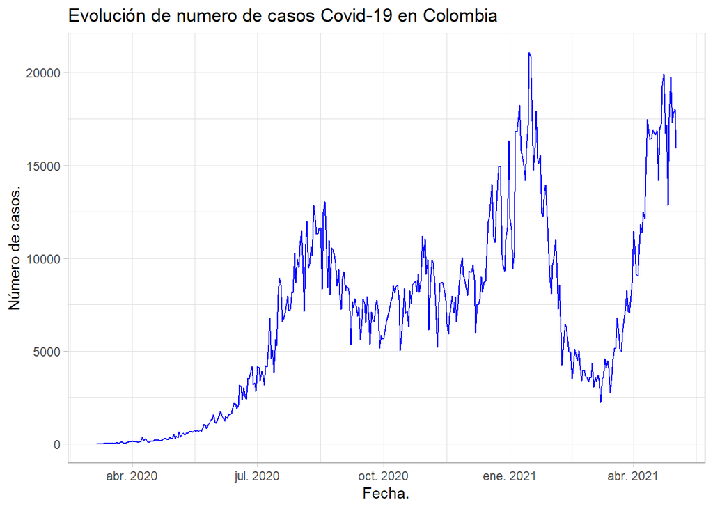

```r
ggplot(Covid19,
       mapping = aes(x = fecha_reporte1,
         y = n)) +
  geom_line(color = "blue") +
  labs(title = "Evolución de numero de casos Covid-19 en Colombia",
       x = "Fecha.",
       y = "Número de casos.") +
  theme_light()
```

6. [Bono por 0,5] Cree una variable que contenga para cada día, el promedio móvil de casos de los 7 días anteriores. Realice el mismo diagrama de líneas pero usando la variable que acaba de crear.
7. Agrégueme como colaborador en el repositorio de Github y publique el link del repositorio, junto con la versión html del notebook en el Aula Virtual, en el espacio que crearé para ello.

**Link del repositorio:** https://github.com/SebastianMorales1/Taller2_Morales